# Project 2 - Technical Report

Douglas Barley, Rachel Greenlee, Sean Connin

5/7/2022

# Project Premise

*This is role playing. I am your new boss. I am in charge of production at ABC Beverage and you are a team of data scientists reporting to me. My leadership has told me that new regulations are requiring us to understand our manufacturing process, the predictive factors and be able to report to them our predictive model of PH.*

# Data Exploration

Our data has already been split into a training and testing dataset, so these are loaded in easily.

```r
# import train and test data
train <- read_csv("training_data.csv")
test <- read_csv("testing_data.csv")
```

Exploring the `train` dataset we see there are 2,571 cases and 33 variables - all of which are numeric except for one character variable. The character variable is `BrandCode` that appears to have 4 unique values.

With regards to missingness, no variable has an alarming amount of missing data - `MFR` has 212 values missing resulting in a complete case percentage of 91.8. We’ll consider imputing missing values dependent on the type of models we choose to try later. We also obverse drastically different scales and ranges of values in the numeric variables, so scaling and centering will be considered dependent on the models selected later.

```r
skim(train)
```

Data summary

| Name | train |
| --- | --- |
| Number of rows | 2571 |
| Number of columns | 33 |
| _______________________ |  |
| Column type frequency: |  |
| character | 1 |
| numeric | 32 |
| ________________________ |  |
| Group variables | None |

**Variable type: character**

| skim_variable | n_missing | complete_rate | min | max | empty | n_unique | whitespace |
| --- | --- | --- | --- | --- | --- | --- | --- |
| Brand Code | 120 | 0.95 | 1 | 1 | 0 | 4 | 0 |

**Variable type: numeric**

| skim_variable | n_missing | complete_rate | mean | sd | p0 | p25 | p50 | p75 | p100 | hist |
| --- | --- | --- | --- | --- | --- | --- | --- | --- | --- | --- |
| Carb Volume | 10 | 1.00 | 5.37 | 0.11 | 5.04 | 5.29 | 5.35 | 5.45 | 5.70 | ▁▆▇▅▁ |
| Fill Ounces | 38 | 0.99 | 23.97 | 0.09 | 23.63 | 23.92 | 23.97 | 24.03 | 24.32 | ▁▂▇▂▁ |
| PC Volume | 39 | 0.98 | 0.28 | 0.06 | 0.08 | 0.24 | 0.27 | 0.31 | 0.48 | ▁▃▇▂▁ |
| Carb Pressure | 27 | 0.99 | 68.19 | 3.54 | 57.00 | 65.60 | 68.20 | 70.60 | 79.40 | ▁▅▇▃▁ |
| Carb Temp | 26 | 0.99 | 141.09 | 4.04 | 128.60 | 138.40 | 140.80 | 143.80 | 154.00 | ▁▅▇▃▁ |
| PSC | 33 | 0.99 | 0.08 | 0.05 | 0.00 | 0.05 | 0.08 | 0.11 | 0.27 | ▆▇▃▁▁ |
| PSC Fill | 23 | 0.99 | 0.20 | 0.12 | 0.00 | 0.10 | 0.18 | 0.26 | 0.62 | ▆▇▃▁▁ |
| PSC CO2 | 39 | 0.98 | 0.06 | 0.04 | 0.00 | 0.02 | 0.04 | 0.08 | 0.24 | ▇▅▂▁▁ |
| Mnf Flow | 2 | 1.00 | 24.57 | 119.48 | -100.20 | -100.00 | 65.20 | 140.80 | 229.40 | ▇▁▁▇▂ |
| Carb Pressure1 | 32 | 0.99 | 122.59 | 4.74 | 105.60 | 119.00 | 123.20 | 125.40 | 140.20 | ▁▃▇▂▁ |
| Fill Pressure | 22 | 0.99 | 47.92 | 3.18 | 34.60 | 46.00 | 46.40 | 50.00 | 60.40 | ▁▁▇▂▁ |
| Hyd Pressure1 | 11 | 1.00 | 12.44 | 12.43 | -0.80 | 0.00 | 11.40 | 20.20 | 58.00 | ▇▅▂▁▁ |
| Hyd Pressure2 | 15 | 0.99 | 20.96 | 16.39 | 0.00 | 0.00 | 28.60 | 34.60 | 59.40 | ▇▂▇▅▁ |
| Hyd Pressure3 | 15 | 0.99 | 20.46 | 15.98 | -1.20 | 0.00 | 27.60 | 33.40 | 50.00 | ▇▁▃▇▁ |
| Hyd Pressure4 | 30 | 0.99 | 96.29 | 13.12 | 52.00 | 86.00 | 96.00 | 102.00 | 142.00 | ▁▃▇▂▁ |
| Filler Level | 20 | 0.99 | 109.25 | 15.70 | 55.80 | 98.30 | 118.40 | 120.00 | 161.20 | ▁▃▅▇▁ |
| Filler Speed | 57 | 0.98 | 3687.20 | 770.82 | 998.00 | 3888.00 | 3982.00 | 3998.00 | 4030.00 | ▁▁▁▁▇ |
| Temperature | 14 | 0.99 | 65.97 | 1.38 | 63.60 | 65.20 | 65.60 | 66.40 | 76.20 | ▇▃▁▁▁ |
| Usage cont | 5 | 1.00 | 20.99 | 2.98 | 12.08 | 18.36 | 21.79 | 23.75 | 25.90 | ▁▃▅▃▇ |
| Carb Flow | 2 | 1.00 | 2468.35 | 1073.70 | 26.00 | 1144.00 | 3028.00 | 3186.00 | 5104.00 | ▂▅▆▇▁ |
| Density | 1 | 1.00 | 1.17 | 0.38 | 0.24 | 0.90 | 0.98 | 1.62 | 1.92 | ▁▅▇▂▆ |
| MFR | 212 | 0.92 | 704.05 | 73.90 | 31.40 | 706.30 | 724.00 | 731.00 | 868.60 | ▁▁▁▂▇ |
| Balling | 1 | 1.00 | 2.20 | 0.93 | -0.17 | 1.50 | 1.65 | 3.29 | 4.01 | ▁▇▇▁▇ |
| Pressure Vacuum | 0 | 1.00 | -5.22 | 0.57 | -6.60 | -5.60 | -5.40 | -5.00 | -3.60 | ▂▇▆▂▁ |
| PH | 4 | 1.00 | 8.55 | 0.17 | 7.88 | 8.44 | 8.54 | 8.68 | 9.36 | ▁▅▇▂▁ |
| Oxygen Filler | 12 | 1.00 | 0.05 | 0.05 | 0.00 | 0.02 | 0.03 | 0.06 | 0.40 | ▇▁▁▁▁ |
| Bowl Setpoint | 2 | 1.00 | 109.33 | 15.30 | 70.00 | 100.00 | 120.00 | 120.00 | 140.00 | ▁▂▃▇▁ |
| Pressure Setpoint | 12 | 1.00 | 47.62 | 2.04 | 44.00 | 46.00 | 46.00 | 50.00 | 52.00 | ▁▇▁▆▁ |
| Air Pressurer | 0 | 1.00 | 142.83 | 1.21 | 140.80 | 142.20 | 142.60 | 143.00 | 148.20 | ▅▇▁▁▁ |
| Alch Rel | 9 | 1.00 | 6.90 | 0.51 | 5.28 | 6.54 | 6.56 | 7.24 | 8.62 | ▁▇▂▃▁ |
| Carb Rel | 10 | 1.00 | 5.44 | 0.13 | 4.96 | 5.34 | 5.40 | 5.54 | 6.06 | ▁▇▇▂▁ |
| Balling Lvl | 1 | 1.00 | 2.05 | 0.87 | 0.00 | 1.38 | 1.48 | 3.14 | 3.66 | ▁▇▂▁▆ |

To take a closer look at our missingness, we check for any frequent patterns of the missing data. For 100 cases only the `MFR` value is missing, and for 91 cases only the `BrandCode` is missing. These are the top two patterns of missingness, and we feel comfortable that these values are ‘missing completely at random’ and not a result of an underlying interaction or phenomena.

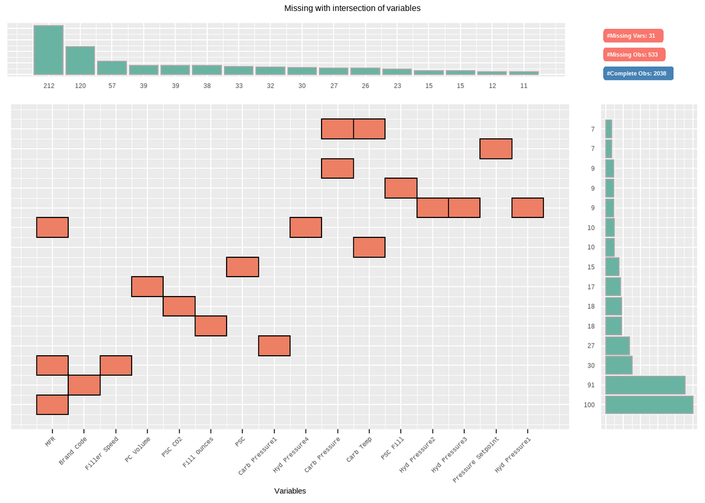

```r
# plotting patterns in missingness, top 15 patterns
train %>%
  plot_na_intersect(only_na = TRUE, typographic = FALSE, n_intersacts = 15)
```

For our numeric variables with missing values, we first check the shape of these variables to see if a mean or median imputation might suffice. From the histograms we see a lot of not-normally distributed variables and many with outliers. This rules out a mean imputation being useful, and while a mode could suffice we’ll choose to use knn imputation when model-building as with this smaller dataset it won’t be computationally challenging.

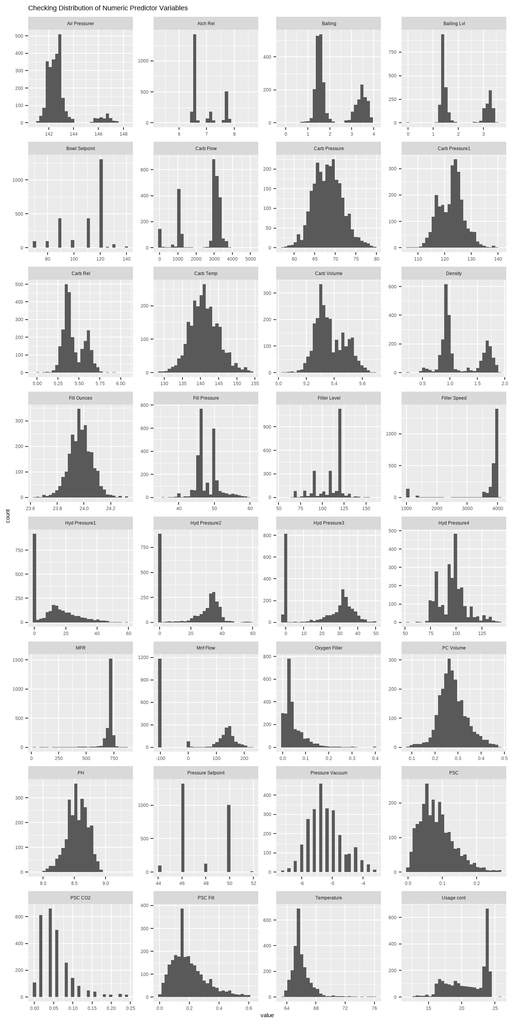

```r
train %>%
  #histograms only for numeric variables
  subset(select = -`Brand Code`) %>%
  #reshape
  gather() %>%
  ggplot(aes(value)) +
  geom_histogram() +
  facet_wrap(~ key, scales = "free", ncol = 4) +
  labs(title = "Checking Distribution of Numeric Predictor Variables")
```

To see if any of the numeric variables may be better served as factors, we look at the above histograms and the following output that shows the count of unique values for each variable. We don’t see any numeric variables that appear to be dichotomous or with only a few levels/values, so we will not switch any of the numeric variables to factors.

```r
var_unique <- lapply(train, unique)
lengths(var_unique)
```

```
##        Brand Code       Carb Volume       Fill Ounces         PC Volume
##                 5               102                93               455
##     Carb Pressure         Carb Temp               PSC          PSC Fill
##               107               124               130                33
##           PSC CO2          Mnf Flow    Carb Pressure1     Fill Pressure
##                14               488               141               109
##     Hyd Pressure1     Hyd Pressure2     Hyd Pressure3     Hyd Pressure4
##               246               208               193                41
##      Filler Level      Filler Speed       Temperature        Usage cont
##               289               245                57               482
##         Carb Flow           Density               MFR           Balling
##               534                79               588               218
##   Pressure Vacuum                PH     Oxygen Filler     Bowl Setpoint
##                16                53               339                12
## Pressure Setpoint     Air Pressurer          Alch Rel          Carb Rel
##                 9                32                54                43
##       Balling Lvl
##                83
```

As it’s hard to visualize all of these variables and their possible correlations, we numerically check for multicollinearity in the training data. We find many variables with greater than (+/-) 0.8. Knowing such, we’ll employ the `step_corr` feature of model recipes to determine which features should be removed due to the colinearity.

```r
train %>%
    #filter_if(is.numeric)%>%
    correlate() %>%
    filter(coef_corr > .8 | coef_corr < -.8)%>% # set thresholds to limit output
    arrange(desc(abs(coef_corr))) %>%
    flextable() %>%
  set_caption('Table 1. Correlated Variables')
```

Table 1. Correlated Variables

| var1 | var2 | coef_corr |
| --- | --- | --- |
| Balling Lvl | Balling | 0.9782085 |
| Balling | Balling Lvl | 0.9782085 |
| Balling | Density | 0.9551553 |
| Density | Balling | 0.9551553 |
| Bowl Setpoint | Filler Level | 0.9489345 |
| Filler Level | Bowl Setpoint | 0.9489345 |
| Balling Lvl | Density | 0.9479195 |
| Density | Balling Lvl | 0.9479195 |
| MFR | Filler Speed | 0.9297119 |
| Filler Speed | MFR | 0.9297119 |
| Balling Lvl | Alch Rel | 0.9258951 |
| Alch Rel | Balling Lvl | 0.9258951 |
| Hyd Pressure3 | Hyd Pressure2 | 0.9248823 |
| Hyd Pressure2 | Hyd Pressure3 | 0.9248823 |
| Alch Rel | Balling | 0.9247934 |
| Balling | Alch Rel | 0.9247934 |
| Alch Rel | Density | 0.9027398 |
| Density | Alch Rel | 0.9027398 |
| Balling Lvl | Carb Rel | 0.8447733 |
| Carb Rel | Balling Lvl | 0.8447733 |
| Carb Rel | Alch Rel | 0.8435849 |
| Alch Rel | Carb Rel | 0.8435849 |
| Carb Rel | Density | 0.8243548 |
| Density | Carb Rel | 0.8243548 |
| Carb Rel | Balling | 0.8224442 |
| Balling | Carb Rel | 0.8224442 |
| Carb Temp | Carb Pressure | 0.8141717 |
| Carb Pressure | Carb Temp | 0.8141717 |